# examples_0320

Consider the $L$-system (and angle) defined below:

- Start: `A++++XA`
- Rules:  
  `A > AA[-B][+B]B`  
  `B > [---ABC][+++ABC]`  
  `C > A[-CB][+CB]`  
  `X > XX`
- Number of recursions (number of iterations):
  - 5
- Angle
  - 45°

Please use [this online tool](https://draemm.li/various/fractals/l-systems/) to generate the pattern using turtle graphics. Choose the matching pattern. (You might need to adjust the `start pos`, `start angle`, and `distance` to center and scale the pattern.)

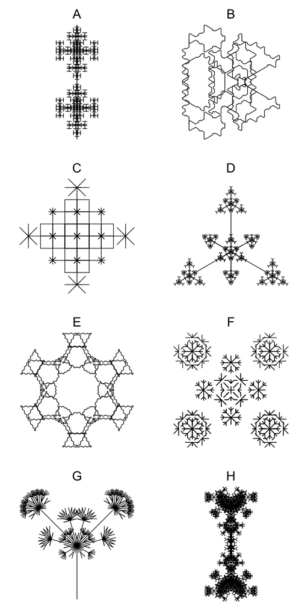

ABCDEFGH

The correct pattern is pattern H.

1. Use the first link: https://draemm.li/various/fractals/l-systems/
2. Copy/paste the `Start`, `Rules`, `Angle`, and `Recursions`.
3. I usually start `Distance` at 1. It can be less than 1, like 0.1, if needed.
4. Click `Run!`
5. If necessary to make the pattern centered and scaled, adjust the `Start pos`, `Start angle`, and `Distance`.
6. Back to the quiz, select the matching pattern.

In case you're interested in the parameters of the other patterns shown:

## Pattern A

- Start: `AA`
- Rules:  
  `A > ABA`  
  `B > C[-BAB][+BAB]`  
  `C > CC`
- Number of recursions (number of iterations):
  - 5
- Angle
  - 90

## Pattern B

- Start: `A`
- Rules:  
  `A > ADB+D+BDA`  
  `B > C-DAD-C`  
  `C > B+A-D-A+B`  
  `D > DD`
- Number of recursions (number of iterations):
  - 5
- Angle
  - 60

## Pattern C

- Start: `A`
- Rules:  
  `A > [----AAB][--AAB][++AAB]AAB`  
  `B > [-C][+C][--C][++C][---C][+++C]`  
  `C > CAB`
- Number of recursions (number of iterations):
  - 3
- Angle
  - 45

## Pattern D

- Start: `A`
- Rules:  
  `A > B[-A][+A]`  
  `B > [DA][--DA][++DA]`  
  `D > DD`
- Number of recursions (number of iterations):
  - 7
- Angle
  - 60

## Pattern E

- Start: `AAAAAA`
- Rules:  
  `A > C--ABA+B+ABA--C`  
  `B > BA+C+AB`  
  `C > -B-CA++AC-B-`
- Number of recursions (number of iterations):
  - 3
- Angle
  - 30

## Pattern F

- Start: `B`
- Rules:  
  `A > [++XXBC][--XXBC][++++XXBC]`  
  `B > [-BA][+BA]`  
  `C > AB`  
  `X > XX`
- Number of recursions (number of iterations):
  - 6
- Angle
  - 45

## Pattern G

- Start: `GA`
- Rules:  
  `A > [---BC][+++BC]`  
  `B > [--AC][++AC]`  
  `C > FF[-BA][+BA]`  
  `F > FF`  
  `G > F`
- Number of recursions (number of iterations):
  - 5
- Angle
  - 15

## Pattern H

- Start: `A++++XA`
- Rules:  
  `A > AA[-B][+B]B`  
  `B > [---ABC][+++ABC]`  
  `C > A[-CB][+CB]`  
  `X > XX`
- Number of recursions (number of iterations):
  - 5
- Angle
  - 45

Consider the $L$-system (and angle) defined below:

- Start: `A++A++A++A`
- Rules:  
  `A > B-ABA-B`  
  `B > A+BB+A`
- Number of recursions (number of iterations):
  - 4
- Angle
  - 135°

Please use [this online tool](https://draemm.li/various/fractals/l-systems/) to generate the pattern using turtle graphics. Choose the matching pattern. (You might need to adjust the `start pos`, `start angle`, and `distance` to center and scale the pattern.)

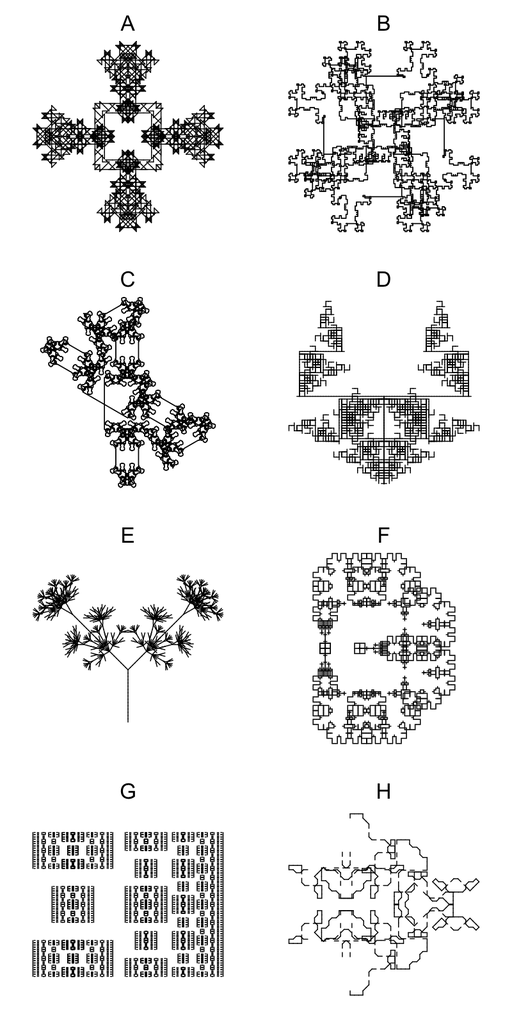

ABCDEFGH

The correct pattern is pattern A.

1. Use the first link: https://draemm.li/various/fractals/l-systems/
2. Copy/paste the `Start`, `Rules`, `Angle`, and `Recursions`.
3. I usually start `Distance` at 1. It can be less than 1, like 0.1, if needed.
4. Click `Run!`
5. If necessary to make the pattern centered and scaled, adjust the `Start pos`, `Start angle`, and `Distance`.
6. Back to the quiz, select the matching pattern.

In case you're interested in the parameters of the other patterns shown:

## Pattern A

- Start: `A++A++A++A`
- Rules:  
  `A > B-ABA-B`  
  `B > A+BB+A`
- Number of recursions (number of iterations):
  - 4
- Angle
  - 135

## Pattern B

- Start: `A+A+A+A`
- Rules:  
  `A > +BA-ACA-BA+`  
  `B > -AB+CBAAABC+BA-`  
  `C > CCCC`
- Number of recursions (number of iterations):
  - 4
- Angle
  - 90

## Pattern C

- Start: `A`
- Rules:  
  `A > +B-ACA-ACA-B+`  
  `B > -A+BCB+BCB+A-`  
  `C > CCC`
- Number of recursions (number of iterations):
  - 5
- Angle
  - 60

## Pattern D

- Start: `[+A][-B]`
- Rules:  
  `A > [-CA-CB]A`  
  `B > [+CB+CA]B`  
  `C > CC`
- Number of recursions (number of iterations):
  - 6
- Angle
  - 90

## Pattern E

- Start: `GA`
- Rules:  
  `A > [---BC][+++BC]`  
  `B > F[--AC][++AC]`  
  `C > FF[-BA][+BA]`  
  `F > FF`  
  `G > F`
- Number of recursions (number of iterations):
  - 5
- Angle
  - 15

## Pattern F

- Start: `A`
- Rules:  
  `A > +BAA-ABA-AAB+`  
  `B > -A+B[-C]B+A-`  
  `C > CCCC[A][+A][-A][--A]`
- Number of recursions (number of iterations):
  - 4
- Angle
  - 90

## Pattern G

- Start: `A`
- Rules:  
  `A > +BX-AA-XB+`  
  `B > -AX+B+XA-`  
  `X > XX`
- Number of recursions (number of iterations):
  - 7
- Angle
  - 90

## Pattern H

- Start: `A`
- Rules:  
  `A > AXB+C+BXA`  
  `B > C--BAB--C`  
  `C > B+D-A-D+B`  
  `X > XX`  
  `D > DD`
- Number of recursions (number of iterations):
  - 4
- Angle
  - 45

Consider the $L$-system (and angle) defined below:

- Start: `ABA`
- Rules:  
  `A > A+AA+B+AA+A`  
  `B > B-B-A-B-B`
- Number of recursions (number of iterations):
  - 4
- Angle
  - 22°

Please use [this online tool](https://draemm.li/various/fractals/l-systems/) to generate the pattern using turtle graphics. Choose the matching pattern. (You might need to adjust the `start pos`, `start angle`, and `distance` to center and scale the pattern.)

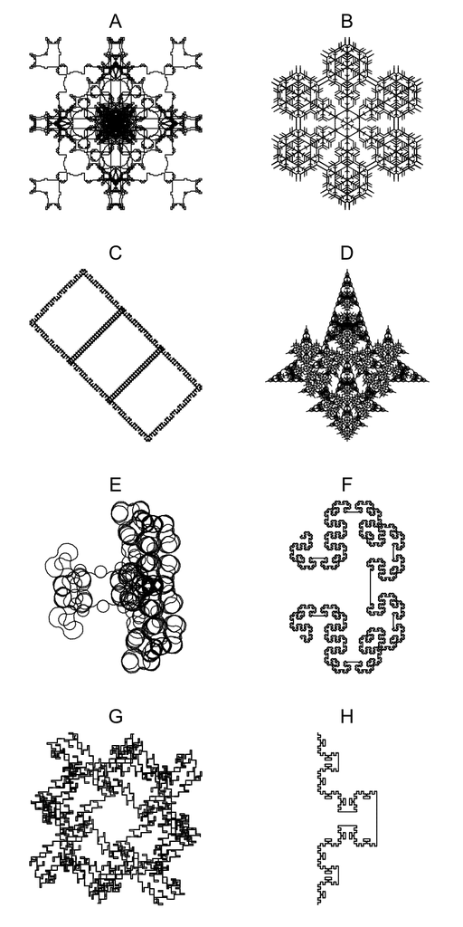

ABCDEFGH

The correct pattern is pattern E.

1. Use the first link: https://draemm.li/various/fractals/l-systems/
2. Copy/paste the `Start`, `Rules`, `Angle`, and `Recursions`.
3. I usually start `Distance` at 1. It can be less than 1, like 0.1, if needed.
4. Click `Run!`
5. If necessary to make the pattern centered and scaled, adjust the `Start pos`, `Start angle`, and `Distance`.
6. Back to the quiz, select the matching pattern.

In case you're interested in the parameters of the other patterns shown:

## Pattern A

- Start: `A++A++A++A`
- Rules:  
  `A > +B-CAC-B+`  
  `B > -A++BB++A-`  
  `C > CC`
- Number of recursions (number of iterations):
  - 6
- Angle
  - 45

## Pattern B

- Start: `[A]+[A]+[A]+[A]+[A]+[A]`
- Rules:  
  `A > AA[-B][+B]B`  
  `B > [-ABC][+ABC]`  
  `C > A[-CB][+CB]`
- Number of recursions (number of iterations):
  - 4
- Angle
  - 60

## Pattern C

- Start: `A`
- Rules:  
  `A > +++BA----ABA----AB+++`  
  `B > ---AB++++BAB++++BA---`
- Number of recursions (number of iterations):
  - 5
- Angle
  - 45

## Pattern D

- Start: `A`
- Rules:  
  `A > A[+A][-A]B`  
  `B > A[--B][++B]B`
- Number of recursions (number of iterations):
  - 6
- Angle
  - 108

## Pattern E

- Start: `ABA`
- Rules:  
  `A > A+AA+B+AA+A`  
  `B > B-B-A-B-B`
- Number of recursions (number of iterations):
  - 4
- Angle
  - 22

## Pattern F

- Start: `A`
- Rules:  
  `A > +BA-ACA-AB+`  
  `B > -AB+BCB+BA-`  
  `C > CCC`
- Number of recursions (number of iterations):
  - 5
- Angle
  - 90

## Pattern G

- Start: `A+A+A+A`
- Rules:  
  `A > C[++CB][--CB]`  
  `B > C-BAB+C`  
  `C > CAB`
- Number of recursions (number of iterations):
  - 6
- Angle
  - 90

## Pattern H

- Start: `-A`
- Rules:  
  `A > A++B-C-B++A`  
  `B > B--A+C+A--B`  
  `C > CCC`
- Number of recursions (number of iterations):
  - 5
- Angle
  - 45